# intro-to-clustering slides

## What's the difference between supervised and unsupervised learning problems?

- Supervised Learning: We have, as part of our training data, observed Y values.
- Unsupervised Learning: We have, as part of our training data, *no* observed Y values.

[figure not shown]

### SUPERVISED LEARNING

**Regression** - Create a model to describe the relationship between X and a continuous Y.

**Classification** - Create a model to describe the relationship between X and a discrete Y.

### UNSUPERVISED LEARNING

**Clustering** - Find groups that already exist in the data.

# Let's come up with examples for each of these.

### Helpful uses for clustering:

- Find items with similar behavior (users, products, voters, etc)
- Market segmentation
- Understand complex systems
- Discover meaningful categories for your data
- Reduce the number of classes by grouping (e.g. bourbons, scotches -> whiskeys)
- Reduce the dimensions of your problem
- Pre-processing! Create labels for supervised learning

# Clustering is incredibly useful. Much like regression and classification use cases became apparent over time, opportunities for clustering will become more obvious as we encounter more examples.

# Much like we talked through NLP, how can we get a computer to algorithmically tell which groups are different?

[figure not shown]

# K Means

### My First<sup>TM</sup> Clustering Algorithm

1. Pick a value for k (the number of clusters to create)
2. Initialize k 'centroids' (starting points) in your data
3. Create your clusters. Assign each point to the nearest centroid.
4. Make your clusters better. Move each centroid to the center of its cluster.
5. Repeat steps 3-4 until your centroids converge.

# K Means

1. Pick a value for k (the number of clusters to create)

[figure not shown]

# K Means

1. Pick a value for k (the number of clusters to create)
2. Initialize k 'centroids' (starting points) in your data

[figure not shown]

# K Means

1. Pick a value for k (the number of clusters to create)
2. Initialize k 'centroids' (starting points) in your data
3. Assign each point to the nearest centroid. These are your 'clusters'.

[figure not shown]

# K Means

1. Pick a value for k (the number of clusters to create)
2. Initialize k 'centroids' (starting points) in your data
3. Assign each point to the nearest centroid. These are your clusters.
4. Make your clusters better. Move each centroid to the center of its cluster.

[figure not shown]

# K Means

1. Pick a value for k (the number of clusters to create)
2. Initialize k 'centroids' (starting points) in your data
3. Assign each point to the nearest centroid. These are your clusters.
4. Make your clusters better. Move each centroid to the center of its cluster.
5. Repeat steps 3-4 until your centroids converge.

[figure not shown]

# K Means

1. Pick a value for k (the number of clusters to create)
2. Initialize k 'centroids' (starting points) in your data
3. Assign each point to the nearest centroid. These are your clusters.
4. Make your clusters better. Move each centroid to the center of its cluster.
5. Repeat steps 3-4 until your centroids converge.

[figure not shown]

# K Means

1. Pick a value for k (the number of clusters to create)
2. Initialize k 'centroids' (starting points) in your data
3. Assign each point to the nearest centroid. These are your clusters.
4. Make your clusters better. Move each centroid to the center of its cluster.
5. Repeat steps 3-4 until your centroids converge.

[figure not shown]

# K Means

1. Pick a value for k (the number of clusters to create)
2. Initialize k 'centroids' (starting points) in your data
3. Assign each point to the nearest centroid. These are your clusters.
4. Make your clusters better. Move each centroid to the center of its cluster.
5. Repeat steps 3-4 until your centroids converge.

[figure not shown]

# K Means

1. Pick a value for k (the number of clusters to create)
2. Initialize k 'centroids' (starting points) in your data
3. Assign each point to the nearest centroid. These are your clusters.
4. Make your clusters better. Move each centroid to the center of its cluster.
5. Repeat steps 3-4 until your centroids converge.

[figure not shown]

# K Means

1. Pick a value for k (the number of clusters to create)
2. Initialize k 'centroids' (starting points) in your data
3. Assign each point to the nearest centroid. These are your clusters.
4. Make your clusters better. Move each centroid to the center of its cluster.
5. Repeat steps 3-4 until your centroids converge.

[figure not shown]

# k-Means is a powerful algorithm, but different starting points may give you different clusters. You won't necessarily get an optimal cluster. (A link to an improved algorithm to initializing centroids for k-means is [here](https://pdfs.semanticscholar.org/b278/74148c4af4d3eedc64909b0b738e5b1c73cf.pdf)).

# Let's practice a toy example by hand. Take a 1-dimensional array of numbers:

```python
arr = [2, 5, 6, 8, 12, 15, 18, 28, 30]
```

Pick `k = 3` random start centroids and let the other points fall into clusters based on the closest centroid. Then, reassign your centroids based on the mean value of your cluster and repeat the process.

Check with your neighbors. Do you have the same clusters? Why or why not?

# Metrics for k-Means

**Inertia** -- sum of squared errors for each cluster (http://scikit-learn.org/stable/modules/clustering.html#k-means)

- Low inertia = dense cluster

**Silhouette Score** -- measure of how far apart clusters are (http://scikit-learn.org/stable/modules/clustering.html#silhouette-coefficient)

- High Silhouette Score = clusters are well-separated

# How do I know which k to pick?

Sometimes you have good context:

- I need to create 14 profiles for marketing to target

Other times you have to figure it out:

- My scatter plots show 2 linearly separable clusters

More on this later this morning.

# Group Practice

Let's do some clustering with the iris dataset.

```python
df = pd.read_csv("assets/datasets/iris.csv")
df.head(5)
```

|  | SepalLength | SepalWidth | PetalLength | PetalWidth | Name |
| --- | --- | --- | --- | --- | --- |
| 0 | 5.1 | 3.5 | 1.4 | 0.2 | Iris-setosa |
| 1 | 4.9 | 3.0 | 1.4 | 0.2 | Iris-setosa |
| 2 | 4.7 | 3.2 | 1.3 | 0.2 | Iris-setosa |
| 3 | 4.6 | 3.1 | 1.5 | 0.2 | Iris-setosa |
| 4 | 5.0 | 3.6 | 1.4 | 0.2 | Iris-setosa |

Our dataset has the categorical column Name in it. K-means does not work well with binary or categorical variables, even if label-enconded or mapped to integers.

Some helpful links on the subject:

- http://stats.stackexchange.com/questions/40613/why-dont-dummy-variables-have-the-continuous-adjacent-category-problem-in-clust
- http://stats.stackexchange.com/questions/174556/k-means-clustering-with-dummy-variables
- http://datascience.stackexchange.com/questions/22/k-means-clustering-for-mixed-numeric-and-categorical-data
- http://www-01.ibm.com/support/docview.wss?uid=swg21477401

```python
X = df[['SepalLength','SepalWidth','PetalLength','PetalWidth']]
```

```python
X.head(2)
```

|  | SepalLength | SepalWidth | PetalLength | PetalWidth |
| --- | --- | --- | --- | --- |
| 0 | 5.1 | 3.5 | 1.4 | 0.2 |
| 1 | 4.9 | 3.0 | 1.4 | 0.2 |

Now let's plot the data to see the distributions:

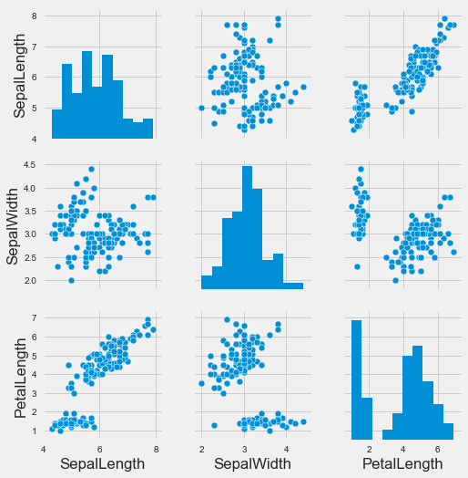

```python
cols = X.columns[:-1]
sns.pairplot(X[cols])
```

# Let's check out the distributions of our data.

```python
X.describe()
```

|  | SepalLength | SepalWidth | PetalLength | PetalWidth |
| --- | --- | --- | --- | --- |
| count | 150.000000 | 150.000000 | 150.000000 | 150.000000 |
| mean | 5.843333 | 3.054000 | 3.758667 | 1.198667 |
| std | 0.828066 | 0.433594 | 1.764420 | 0.763161 |
| min | 4.300000 | 2.000000 | 1.000000 | 0.100000 |
| 25% | 5.100000 | 2.800000 | 1.600000 | 0.300000 |
| 50% | 5.800000 | 3.000000 | 4.350000 | 1.300000 |
| 75% | 6.400000 | 3.300000 | 5.100000 | 1.800000 |
| max | 7.900000 | 4.400000 | 6.900000 | 2.500000 |

# What are some concerns that we might have here?

```python
X_scaled = preprocessing.normalize(X,axis=0)
```

```python
pd.DataFrame(X_scaled, columns=X.columns).describe()
```

|  | SepalLength | SepalWidth | PetalLength | PetalWidth |
| --- | --- | --- | --- | --- |
| count | 150.000000 | 150.000000 | 150.000000 | 150.000000 |
| mean | 0.080847 | 0.080844 | 0.073956 | 0.068941 |
| std | 0.011457 | 0.011478 | 0.034717 | 0.043893 |
| min | 0.059494 | 0.052943 | 0.019676 | 0.005751 |
| 25% | 0.070563 | 0.074121 | 0.031482 | 0.017254 |
| 50% | 0.080248 | 0.079415 | 0.085591 | 0.074769 |
| 75% | 0.088549 | 0.087356 | 0.100348 | 0.103527 |
| max | 0.109303 | 0.116475 | 0.135765 | 0.143787 |

Now that we've formatted our data and understand it's structures, we can finally go ahead and cluster.

```python
k = 3
kmeans = cluster.KMeans(n_clusters=k)
kmeans.fit(X_scaled)
```

```
KMeans(algorithm='auto', copy_x=True, init='k-means++', max_iter=300,
    n_clusters=3, n_init=10, n_jobs=1, precompute_distances='auto',
    random_state=None, tol=0.0001, verbose=0)
```

We can use sklearn's built-in functions to determine the locations of the labels, centroids, and cluster inertia:

```python
labels = kmeans.labels_
centroids = kmeans.cluster_centers_
inertia = kmeans.inertia_

print 'Labels:', labels
print ''
print 'Centroids:', centroids
print ''
print 'Inertia:', inertia
```

```
Labels: [0 0 0 0 0 0 0 0 0 0 0 0 0 0 0 0 0 0 0 0 0 0 0 0 0 0 0 0 0 0 0 0 0 0 0 0 0
 0 0 0 0 0 0 0 0 0 0 0 0 0 1 1 1 1 1 1 1 1 1 1 1 1 1 1 1 1 1 1 1 1 2 1 1 1
 1 1 1 2 1 1 1 1 1 1 1 1 1 1 1 1 1 1 1 1 1 1 1 1 1 1 2 2 2 2 2 2 1 2 2 2 2
 2 2 2 2 2 2 2 2 1 2 2 2 2 2 2 2 2 2 2 2 2 2 1 1 2 2 2 2 2 2 2 2 2 2 2 2 2
 2 2]

Centroids: [[ 0.06926207  0.09047997  0.02880573  0.01403365]
 [ 0.08181754  0.07249149  0.08453131  0.07620734]
 [ 0.09186403  0.07985603  0.10952998  0.11826516]]

Inertia: 0.0461817429818
```

And to compute the clusters' silhouette coefficient:

```python
print 'Silhouette Score:', metrics.silhouette_score(X_scaled, labels, metric='euclidean')
```

```
Silhouette Score: 0.603284978223
```

...and we're done! You've completed your first clustering analysis.

Let's see how it looks. First, let's put the labels columns into our dataframe

```python
df['label'] = labels
X['label'] = labels
df
```

|  | SepalLength | SepalWidth | PetalLength | PetalWidth | Name | label |
| --- | --- | --- | --- | --- | --- | --- |
| 0 | 5.1 | 3.5 | 1.4 | 0.2 | Iris-setosa | 0 |
| 1 | 4.9 | 3.0 | 1.4 | 0.2 | Iris-setosa | 0 |
| 2 | 4.7 | 3.2 | 1.3 | 0.2 | Iris-setosa | 0 |
| 3 | 4.6 | 3.1 | 1.5 | 0.2 | Iris-setosa | 0 |
| 4 | 5.0 | 3.6 | 1.4 | 0.2 | Iris-setosa | 0 |
| 5 | 5.4 | 3.9 | 1.7 | 0.4 | Iris-setosa | 0 |
| 6 | 4.6 | 3.4 | 1.4 | 0.3 | Iris-setosa | 0 |
| 7 | 5.0 | 3.4 | 1.5 | 0.2 | Iris-setosa | 0 |
| 8 | 4.4 | 2.9 | 1.4 | 0.2 | Iris-setosa | 0 |
| 9 | 4.9 | 3.1 | 1.5 | 0.1 | Iris-setosa | 0 |
| 10 | 5.4 | 3.7 | 1.5 | 0.2 | Iris-setosa | 0 |
| 11 | 4.8 | 3.4 | 1.6 | 0.2 | Iris-setosa | 0 |
| 12 | 4.8 | 3.0 | 1.4 | 0.1 | Iris-setosa | 0 |
| 13 | 4.3 | 3.0 | 1.1 | 0.1 | Iris-setosa | 0 |
| 14 | 5.8 | 4.0 | 1.2 | 0.2 | Iris-setosa | 0 |
| 15 | 5.7 | 4.4 | 1.5 | 0.4 | Iris-setosa | 0 |
| 16 | 5.4 | 3.9 | 1.3 | 0.4 | Iris-setosa | 0 |
| 17 | 5.1 | 3.5 | 1.4 | 0.3 | Iris-setosa | 0 |
| 18 | 5.7 | 3.8 | 1.7 | 0.3 | Iris-setosa | 0 |
| 19 | 5.1 | 3.8 | 1.5 | 0.3 | Iris-setosa | 0 |
| 20 | 5.4 | 3.4 | 1.7 | 0.2 | Iris-setosa | 0 |
| 21 | 5.1 | 3.7 | 1.5 | 0.4 | Iris-setosa | 0 |
| 22 | 4.6 | 3.6 | 1.0 | 0.2 | Iris-setosa | 0 |
| 23 | 5.1 | 3.3 | 1.7 | 0.5 | Iris-setosa | 0 |
| 24 | 4.8 | 3.4 | 1.9 | 0.2 | Iris-setosa | 0 |
| 25 | 5.0 | 3.0 | 1.6 | 0.2 | Iris-setosa | 0 |
| 26 | 5.0 | 3.4 | 1.6 | 0.4 | Iris-setosa | 0 |
| 27 | 5.2 | 3.5 | 1.5 | 0.2 | Iris-setosa | 0 |
| 28 | 5.2 | 3.4 | 1.4 | 0.2 | Iris-setosa | 0 |
| 29 | 4.7 | 3.2 | 1.6 | 0.2 | Iris-setosa | 0 |
| ... | ... | ... | ... | ... | ... | ... |
| 120 | 6.9 | 3.2 | 5.7 | 2.3 | Iris-virginica | 2 |
| 121 | 5.6 | 2.8 | 4.9 | 2.0 | Iris-virginica | 2 |
| 122 | 7.7 | 2.8 | 6.7 | 2.0 | Iris-virginica | 2 |
| 123 | 6.3 | 2.7 | 4.9 | 1.8 | Iris-virginica | 2 |
| 124 | 6.7 | 3.3 | 5.7 | 2.1 | Iris-virginica | 2 |
| 125 | 7.2 | 3.2 | 6.0 | 1.8 | Iris-virginica | 2 |
| 126 | 6.2 | 2.8 | 4.8 | 1.8 | Iris-virginica | 2 |
| 127 | 6.1 | 3.0 | 4.9 | 1.8 | Iris-virginica | 2 |
| 128 | 6.4 | 2.8 | 5.6 | 2.1 | Iris-virginica | 2 |
| 129 | 7.2 | 3.0 | 5.8 | 1.6 | Iris-virginica | 2 |
| 130 | 7.4 | 2.8 | 6.1 | 1.9 | Iris-virginica | 2 |
| 131 | 7.9 | 3.8 | 6.4 | 2.0 | Iris-virginica | 2 |
| 132 | 6.4 | 2.8 | 5.6 | 2.2 | Iris-virginica | 2 |
| 133 | 6.3 | 2.8 | 5.1 | 1.5 | Iris-virginica | 1 |
| 134 | 6.1 | 2.6 | 5.6 | 1.4 | Iris-virginica | 1 |
| 135 | 7.7 | 3.0 | 6.1 | 2.3 | Iris-virginica | 2 |
| 136 | 6.3 | 3.4 | 5.6 | 2.4 | Iris-virginica | 2 |
| 137 | 6.4 | 3.1 | 5.5 | 1.8 | Iris-virginica | 2 |
| 138 | 6.0 | 3.0 | 4.8 | 1.8 | Iris-virginica | 2 |
| 139 | 6.9 | 3.1 | 5.4 | 2.1 | Iris-virginica | 2 |
| 140 | 6.7 | 3.1 | 5.6 | 2.4 | Iris-virginica | 2 |
| 141 | 6.9 | 3.1 | 5.1 | 2.3 | Iris-virginica | 2 |
| 142 | 5.8 | 2.7 | 5.1 | 1.9 | Iris-virginica | 2 |
| 143 | 6.8 | 3.2 | 5.9 | 2.3 | Iris-virginica | 2 |
| 144 | 6.7 | 3.3 | 5.7 | 2.5 | Iris-virginica | 2 |
| 145 | 6.7 | 3.0 | 5.2 | 2.3 | Iris-virginica | 2 |
| 146 | 6.3 | 2.5 | 5.0 | 1.9 | Iris-virginica | 2 |
| 147 | 6.5 | 3.0 | 5.2 | 2.0 | Iris-virginica | 2 |
| 148 | 6.2 | 3.4 | 5.4 | 2.3 | Iris-virginica | 2 |
| 149 | 5.9 | 3.0 | 5.1 | 1.8 | Iris-virginica | 2 |

150 rows × 6 columns

Let's plot each cluster in a different color. Seaborn has a 'hue' parameter we can use for this.

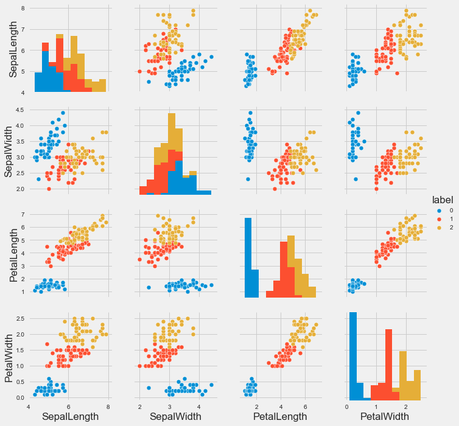

```python
cols = X.columns[:-1]
sns.pairplot(X, x_vars=cols, y_vars= cols, hue='label')
```

Just for comparison, here's the data colored by name of the plant.

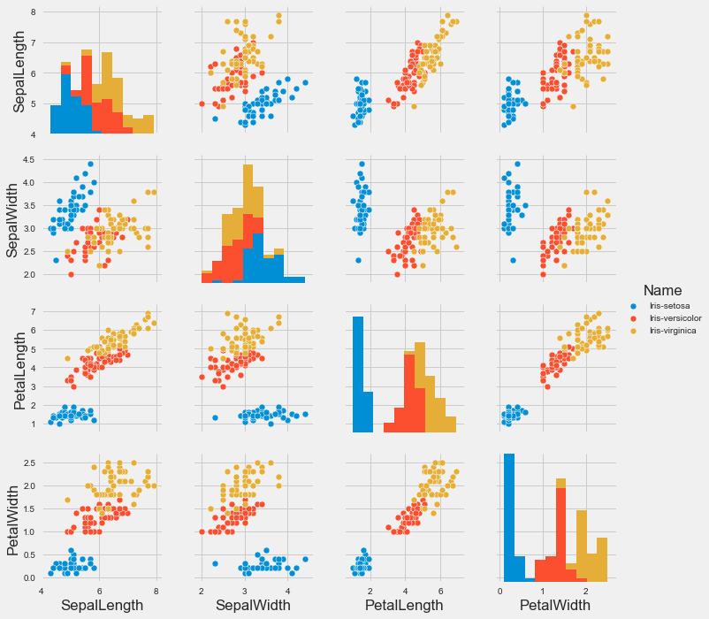

```python
sns.pairplot(df, x_vars=cols, y_vars= cols, hue='Name')
```

# Independent Practice: Perform a K-Means Analysis

Now that we've walked through the process of clustering, it's time to try it on your own. We're going to be working with the `mtcars` data set, and your job is to cluster these cars to understand their various attributes. (You've used this a ton - use your knowledge of relative filenames to pull the right data!)

The dataset contains a listing of 33 different cars from a used car dealership - your task is the cluster the cars to discover their groupings. For each car, you have a variety of technical information related to the car's performance.

Open the data and try to work through both exercises with a partner. Briefly summarize the two variables you chose and explain how your plots demonstrate the data.

# Wrap Up Multiple Choice

### Which of the following is an unsupervised learning problem?

A. Predicting a store's sales.

B. Grouping stores by state.

C. Grouping stores by demographic profiles.

### How might we find k for a k-Means clustering problem?

A. Treat k as a tuning parameter and use some cross-validation to find the most appropriate value of k.

B. Rely on subject-matter expertise to recognize how many clusters to create.

C. Visually examine scatterplots.

### What are drawbacks to the k-means method? (Plot twist; not a multiple choice question!)

# Resources

- [Sci-Kit Learn Clustering Overview](http://scikit-learn.org/stable/modules/clustering.html#k-means)
- [SKLearn K-Means Documentation](http://scikit-learn.org/stable/modules/generated/sklearn.cluster.KMeans.html#sklearn.cluster.KMeans)
- [SKLearn Clustering Code - See _k_init__ for explanation of k++ centroid selection](https://github.com/scikit-learn/scikit-learn/blob/51a765a/sklearn/cluster/k_means_.py#L769)
- [Clustering Tutorial](http://home.deib.polimi.it/matteucc/Clustering/tutorial_html/)
- [Wikipedia's Deep Dive on Clustering](https://en.wikipedia.org/wiki/K-means_clustering)
- [An excellent blog from Galvanize on K-Means Clustering](http://www.galvanize.com/blog/introduction-k-means-cluster-analysis/#.V9aXqpOAOkp)